# Sample Metadata Analysis

Christina Schmidt

Heidelberg University

[figure not shown]

Tissue metabolomics experiment is a standard metabolomics experiment using tissue samples (e.g. from animals or patients).  
In this tutorial we showcase how to use **MetaProViz**:

- to perform differential metabolite analysis (dma) to generate Log2FC and statistics and perform pathway analysis using Over Representation Analysis (ORA) on the results.
- to do metabolite clustering analysis (MCA) to find clusters of metabolites with similar behaviors based on patients demographics like age, gender and tumour stage.
- Find the main metabolite drivers that separate patients based on their demographics like age, gender and tumour stage.  
  First if you have not done yet, install the required dependencies and load the libraries:

```r
# 1. Install Rtools if you haven’t done this yet, using the appropriate version (e.g.windows or macOS).
# 2. Install the latest development version from GitHub using devtools
# devtools::install_github("https://github.com/saezlab/MetaProViz")

library(MetaProViz)

# dependencies that need to be loaded:
library(magrittr)
library(dplyr)
library(rlang)
library(tidyr)
library(tibble)
library(stringr)

# Please install the Biocmanager Dependencies:
# BiocManager::install("clusterProfiler")
# BiocManager::install("EnhancedVolcano")
```

# 1. Loading the example data

Here we choose an example datasets, which is publicly available in the paper “An Integrated Metabolic Atlas of Clear Cell Renal Cell Carcinoma”, which includes metabolomic profiling on 138 matched clear cell renal cell carcinoma (ccRCC)/normal tissue pairs (Hakimi et al. 2016). Metabolomics was done using The company Metabolon, so this is untargeted metabolomics. Here we use the median normalised data from the supplementary table 2 of the paper. We have combined the metainformation about the patients with the metabolite measurements and removed unidentified metabolites. Lastly, we have added a column “Stage” where Stage1 and Stage2 patients are summarised to “EARLY-STAGE” and Stage3 and Stage4 patients to “LATE-STAGE”. Moreover, we have added a column “Age”, where patients with “AGE AT SURGERY” <42 are defined as “Young” and patients with AGE AT SURGERY >58 as “Old” and the remaining patients as “Middle”.

#As part of the **MetaProViz** package you can load the example data into your global environment using the function `toy_data()`:  
`1.` Tissue experiment **(Intra)**  
We can access the built-in dataset `tissue_norm`, which includes columns with Sample information and columns with the median normalised measured metabolite integrated peaks.

```r
# Load the example data:
Tissue_Norm <- tissue_norm%>%
  column_to_rownames("Code")
```

Preview of the DF `Tissue_Norm` including columns with sample information and metabolite ids with their measured values.

|  | TISSUE_TYPE | GENDER | AGE_AT_SURGERY | TYPE-STAGE | STAGE | AGE | 1,2-propanediol | 1,3-dihydroxyacetone |
| --- | --- | --- | --- | --- | --- | --- | --- | --- |
| DIAG-16076 | TUMOR | Male | 74.7778 | TUMOR-STAGE I | EARLY-STAGE | Old | 0.710920 | 0.809182 |
| DIAG-16077 | NORMAL | Male | 74.7778 | NORMAL-STAGE I | EARLY-STAGE | Old | 0.339390 | 0.718725 |
| DIAG-16078 | TUMOR | Male | 77.1778 | TUMOR-STAGE I | EARLY-STAGE | Old | 0.413386 | 0.276412 |
| DIAG-16079 | NORMAL | Male | 77.1778 | NORMAL-STAGE I | EARLY-STAGE | Old | 1.595697 | 4.332451 |
| DIAG-16080 | TUMOR | Female | 59.0889 | TUMOR-STAGE I | EARLY-STAGE | Old | 0.573787 | 0.646791 |

`2.` Additional information mapping the trivial metabolite names to KEGG IDs, HMDB IDs, etc. and selected pathways **(MappingInfo)**

```r
Tissue_MetaData <- tissue_meta%>%
  column_to_rownames("Metabolite")
```

Preview of the DF `Tissue_MetaData` including the trivial metabolite identifiers used in the experiment as well as IDs and pathway information.

|  | SUPER_PATHWAY | SUB_PATHWAY | CAS | PUBCHEM | KEGG | Group_HMDB |
| --- | --- | --- | --- | --- | --- | --- |
| 1,2-propanediol | Lipid | Ketone bodies | 57-55-6; | NA | C00583 | HMDB01881 |
| 1,3-dihydroxyacetone | Carbohydrate | Glycolysis, gluconeogenesis, pyruvate metabolism | 62147-49-3; | 670 | C00184 | HMDB01882 |
| 1,5-anhydroglucitol (1,5-AG) | Carbohydrate | Glycolysis, gluconeogenesis, pyruvate metabolism | 154-58-5; | NA | C07326 | HMDB02712 |
| 10-heptadecenoate (17:1n7) | Lipid | Long chain fatty acid | 29743-97-3; | 5312435 | NA | NA |
| 10-nonadecenoate (19:1n9) | Lipid | Long chain fatty acid | 73033-09-7; | 5312513 | NA | NA |

# 2. Run MetaProViz Analysis

## Pre-processing

This has been done by the authors of the paper and we will use the median normalized data. If you want to know how you can use the **MetaProViz** pre-processing module, please check out the vignette:  
- [Standard metabolomics data](https://saezlab.github.io/MetaProViz/articles/Standard%20Metabolomics.html)  
- [Consumption-Release (core) metabolomics data from cell culture media](https://saezlab.github.io/MetaProViz/articles/core%20Metabolomics.html)

## Metadata analysis

We can use the patient’s metadata to find the main metabolite drivers that separate patients based on their demographics like age, gender, etc.  
Here the metadata analysis is based on principal component analysis (PCA), which is a dimensionality reduction method that reduces all the measured features (=metabolites) of one sample into a few features in the different principal components, whereby each principal component can explain a certain percentage of the variance between the different samples. Hence, this enables interpretation of sample clustering based on the measured features (=metabolites).  
The `MetaProViz::metadata_analysis()` function will perform PCA to extract the different PCs followed by annova to find the main metabolite drivers that separate patients based on their demographics.

```
#> The column names of the 'metadata_sample' contain special character that where removed.
```

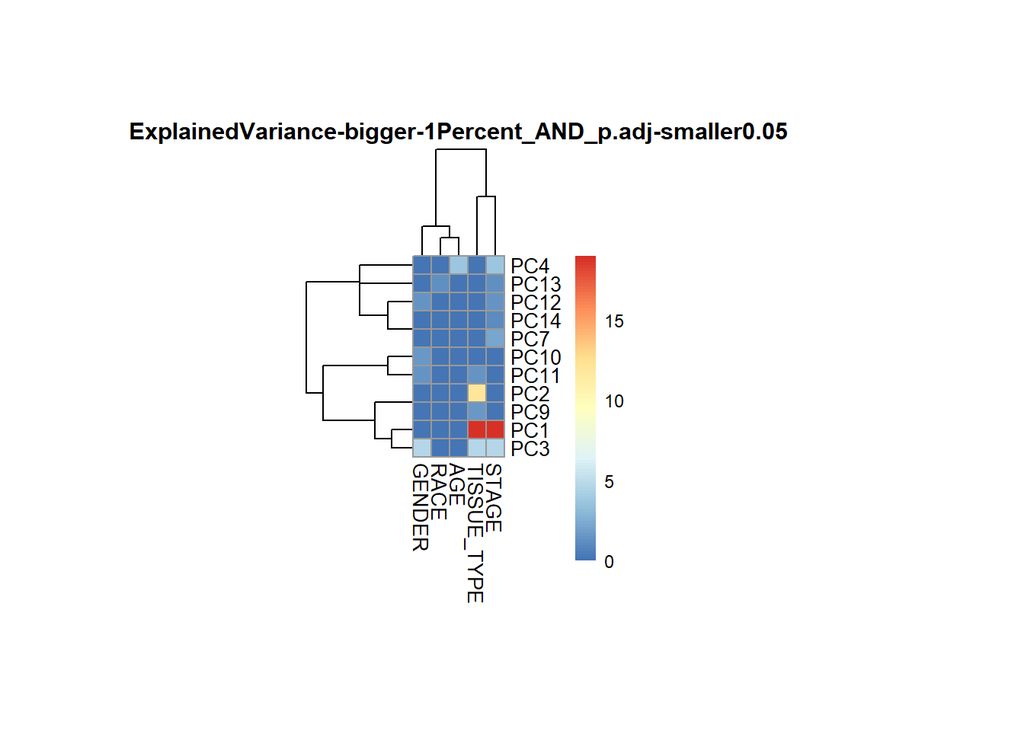

```r
MetaRes <- MetaProViz::metadata_analysis(data=Tissue_Norm[,-c(1:13)],
                                     metadata_sample= Tissue_Norm[,c(2,4:5,12:13)],
                                     scaling = TRUE,
                                     percentage = 0.1,
                                     cutoff_stat= 0.05,
                                     cutoff_variance = 1)
```

Ultimately, this is leading to clusters of metabolites that are driving the separation of the different demographics.  
We generated the general anova output DF:

Preview of the DF MetaRes[[`res_aov`]] including the main metabolite drivers that separate patients based on their demographics.

|  | PC | tukeyHSD_Contrast | term | anova_sumsq | anova_meansq | anova_statistic | anova_p.value | tukeyHSD_p.adjusted | Explained_Variance |
| --- | --- | --- | --- | --- | --- | --- | --- | --- | --- |
| 1 | PC1 | TUMOR-NORMAL | TISSUE_TYPE | 7375.2212254 | 7375.2212254 | 90.1352800 | 0.0000000 | 0.0000000 | 19.0079573 |
| 2 | PC1 | Black-Asian | RACE | 156.7549451 | 52.2516484 | 0.4795311 | 0.6967838 | 0.9992824 | 19.0079573 |
| 1777 | PC232 | White-Asian | RACE | 0.2726952 | 0.0908984 | 0.9544580 | 0.4147472 | 0.5495634 | 0.0166997 |
| 1778 | PC232 | LATE-STAGE-EARLY-STAGE | STAGE | 0.0360319 | 0.0360319 | 0.3776760 | 0.5393596 | 0.5393596 | 0.0166997 |
| 3191 | PC9 | White-Other | RACE | 20.2626222 | 6.7542074 | 0.7090398 | 0.5473277 | 0.8897908 | 1.6658973 |
| 3192 | PC9 | Young-Middle | AGE | 49.2030973 | 24.6015486 | 2.6213834 | 0.0745317 | 0.9979475 | 1.6658973 |

We generated the summarised results output DF, where each feature (=metabolite) was assigned a main demographics parameter this feature is separating:

Preview of the DF MetaRes[[`res_summary`]] including the metabolite drivers in rows and list the patients demographics they can separate.

| feature | term | Sum(Explained_Variance) | MainDriver | MainDriver_Term | MainDriver_Sum(VarianceExplained) |
| --- | --- | --- | --- | --- | --- |
| N2-methylguanosine | AGE, GENDER, RACE, STAGE, TISSUE_TYPE | 3.7598809871366, 2.75344828467363, 1.43932034747081, 25.2803273612931, 33.9484968841434 | FALSE, FALSE, FALSE, FALSE, TRUE | TISSUE_TYPE | 33.9485 |
| 5-methyltetrahydrofolate (5MeTHF) | AGE, GENDER, RACE, STAGE, TISSUE_TYPE | 0.35114340819656, 0.29468807988021, 0.252515004077172, 19.4058160726611, 32.5442969233501 | FALSE, FALSE, FALSE, FALSE, TRUE | TISSUE_TYPE | 32.5443 |
| N-acetylalanine | AGE, GENDER, RACE, STAGE, TISSUE_TYPE | 0.381811888038144, 1.82507161869685, 2.97460134435356, 19.0079573465896, 32.5442969233501 | FALSE, FALSE, FALSE, FALSE, TRUE | TISSUE_TYPE | 32.5443 |
| N-acetyl-aspartyl-glutamate (NAAG) | AGE, GENDER, RACE, STAGE, TISSUE_TYPE | 0.212976478603115, 2.75344828467363, 0.235952044704099, 20.3572056704699, 32.2825995362096 | FALSE, FALSE, FALSE, FALSE, TRUE | TISSUE_TYPE | 32.2826 |
| 1-heptadecanoylglycerophosphoethanolamine* | AGE, GENDER, RACE, STAGE, TISSUE_TYPE | 4.33031140898825, 0.267851018697989, 0.437853800763464, 22.8424358182214, 30.8783995754163 | FALSE, FALSE, FALSE, FALSE, TRUE | TISSUE_TYPE | 30.8784 |
| 1-linoleoylglycerophosphoethanolamine* | AGE, STAGE, TISSUE_TYPE | 4.2011500430443, 22.7555733683955, 30.8783995754163 | FALSE, FALSE, TRUE | TISSUE_TYPE | 30.8784 |

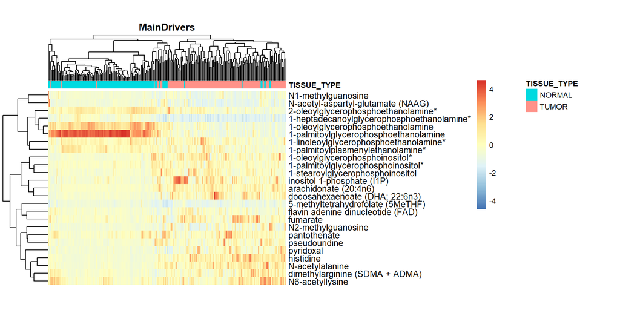

```r
##1. Tissue_Type
TissueTypeList <- MetaRes[["res_summary"]]%>%
  filter(MainDriver_Term == "TISSUE_TYPE")%>%
  filter(`MainDriver_Sum(VarianceExplained)`>30)%>%
  select(feature)%>%
  pull()

# select columns tissue_norm that are in TissueTypeList if they exist
Input_Heatmap <- Tissue_Norm[ , names(Tissue_Norm) %in% TissueTypeList]#c("N1-methylguanosine", "N-acetylalanine", "lysylmethionine")

# Heatmap: Metabolites that separate the demographics, like here TISSUE_TYPE
MetaProViz:::viz_heatmap(data = Input_Heatmap,
                       metadata_sample = Tissue_Norm[,c(1:13)],
                       metadata_info = c(color_Sample = list("TISSUE_TYPE")),
                       scale ="column",
                      plot_name = "MainDrivers")
```

## DMA

Here we use Differential Metabolite Analysis (`dma`) to compare two conditions (e.g. Tumour versus Healthy) by calculating the Log2FC, p-value, adjusted p-value and t-value.  
For more information please see the vignette:  
- [Standard metabolomics data](https://saezlab.github.io/MetaProViz/articles/Standard%20Metabolomics.html)  
- [Consumption-Release (core) metabolomics data from cell culture media](https://saezlab.github.io/MetaProViz/articles/core%20Metabolomics.html)  
We will perform multiple comparisons based on the different patient demographics available: 1. Tumour versus Normal: All patients 2. Tumour versus Normal: Subset of `Early Stage` patients 3. Tumour versus Normal: Subset of `Late Stage` patients 4. Tumour versus Normal: Subset of `Young` patients 5. Tumour versus Normal: Subset of `Old` patients

```
#> Running dma for TissueType
#> There are no NA/0 values
```

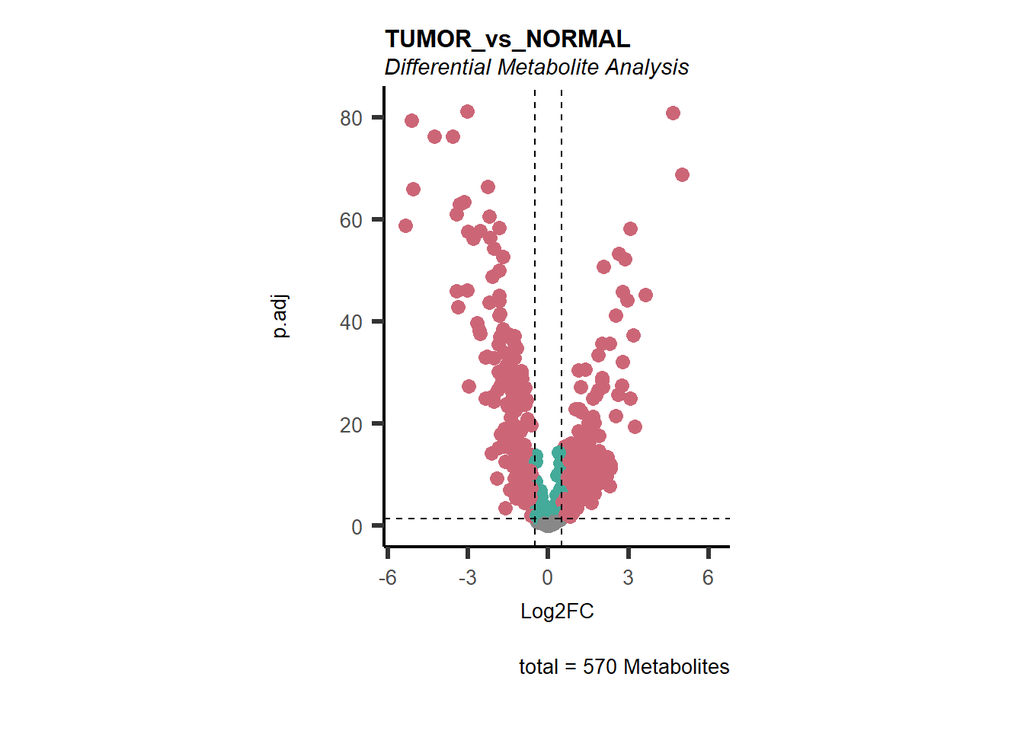

```
#> Running dma for EarlyStage
#> There are no NA/0 values
```

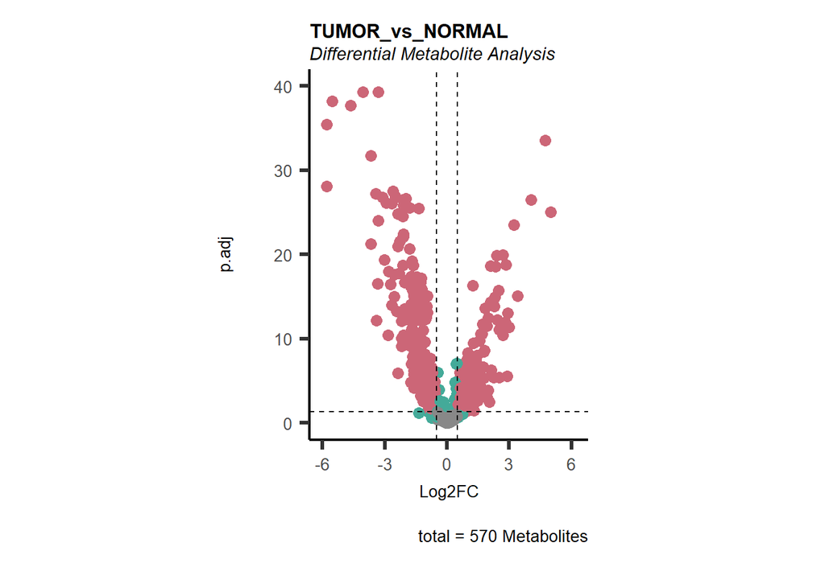

```
#> Running dma for LateStage
#> There are no NA/0 values
```

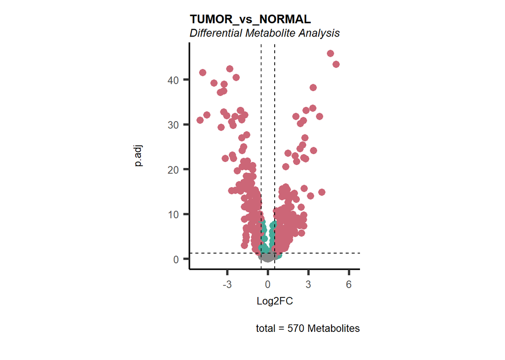

```
#> Running dma for Old
#> There are no NA/0 values
```

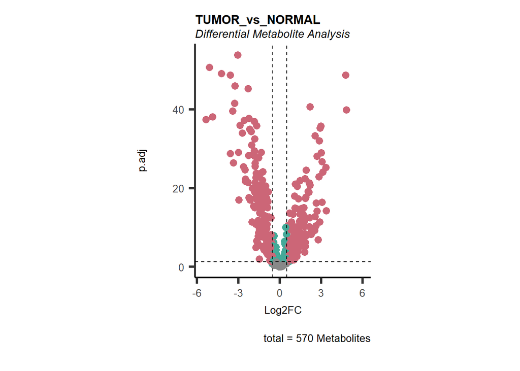

```
#> Running dma for Young
#> There are no NA/0 values
```

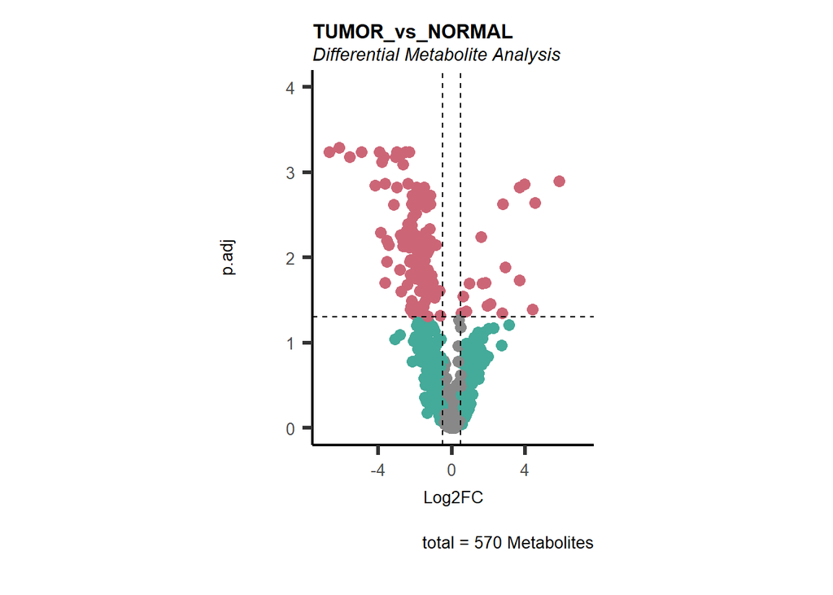

```r
# Prepare the different selections
EarlyStage <- Tissue_Norm %>%
  filter(STAGE== "EARLY-STAGE")
LateStage <- Tissue_Norm %>%
  filter(STAGE=="LATE-STAGE")
Old <- Tissue_Norm %>%
  filter(AGE=="Old")
Young <- Tissue_Norm%>%
  filter(AGE=="Young")

DFs <- list("TissueType"= Tissue_Norm,"EarlyStage"= EarlyStage, "LateStage"= LateStage, "Old"= Old, "Young"=Young)

# Run dma
ResList <- list()
for(item in names(DFs)){
  #Get the right DF:
  data <- DFs[[item]]

  message(paste("Running dma for", item))
  #Create folder for saving each comparison
  dir.create(paste(getwd(),"/MetaProViz_Results/dma/", sep=""), showWarnings = FALSE)
  dir.create(paste(getwd(),"/MetaProViz_Results/dma/", item, sep=""), showWarnings = FALSE)

  #Perform dma
  set.seed(100)
  TvN <- MetaProViz::dma(data =  data[,-c(1:13)],
                   metadata_sample =  data[,c(1:13)],
                   metadata_info = c(Conditions="TISSUE_TYPE", Numerator="TUMOR" , Denominator = "NORMAL"),
                   shapiro=FALSE, #The data have been normalized by the company that provided the results and include metabolites with zero variance as they were all imputed with the same missing value.
                   path = paste(getwd(),"/MetaProViz_Results/dma/", item, sep=""))

  #Add Results to list
  ResList[[item]] <- TvN
}
```

We can see from the different Volcano plots have smaller p.adjusted values and differences in Log2FC range.  
Here we can also use the `MetaproViz::viz_volcano()` function to plot comparisons together on the same plot, such as Tumour versus Normal of young and old patients:

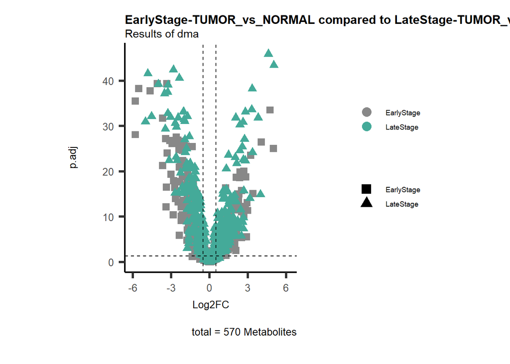

```r
# Early versus Late Stage
MetaProViz::viz_volcano(plot_types="Compare",
                       data=ResList[["EarlyStage"]][["dma"]][["TUMOR_vs_NORMAL"]]%>%tibble::column_to_rownames("Metabolite"),
                       data2= ResList[["LateStage"]][["dma"]][["TUMOR_vs_NORMAL"]]%>%tibble::column_to_rownames("Metabolite"),
                       name_comparison= c(data="EarlyStage", data2= "LateStage"),
                       plot_name= "EarlyStage-TUMOR_vs_NORMAL compared to LateStage-TUMOR_vs_NORMAL",
                       subtitle= "Results of dma" )
```

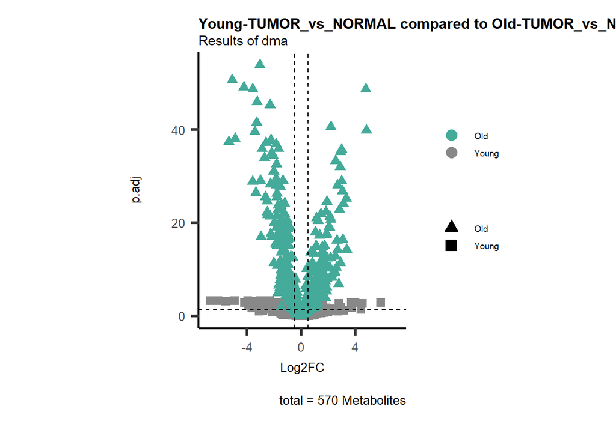

```r
# Young versus Old
MetaProViz::viz_volcano(plot_types="Compare",
                       data=ResList[["Young"]][["dma"]][["TUMOR_vs_NORMAL"]]%>%tibble::column_to_rownames("Metabolite"),
                       data2= ResList[["Old"]][["dma"]][["TUMOR_vs_NORMAL"]]%>%tibble::column_to_rownames("Metabolite"),
                       name_comparison= c(data="Young", data2= "Old"),
                       plot_name= "Young-TUMOR_vs_NORMAL compared to Old-TUMOR_vs_NORMAL",
                       subtitle= "Results of dma" )
```

Here we can observe that Tumour versus Normal has lower significance values for the Young patients compared to the Old patients. This can be due to higher variance in the metabolite measurements from Young patients compared to the Old patients.  
We can also check if the top changed metabolites comparing Tumour versus Normal correlate with the main metabolite drivers that separate patients based on their `TISSUE_TYPE`, which are Tumour or Normal.

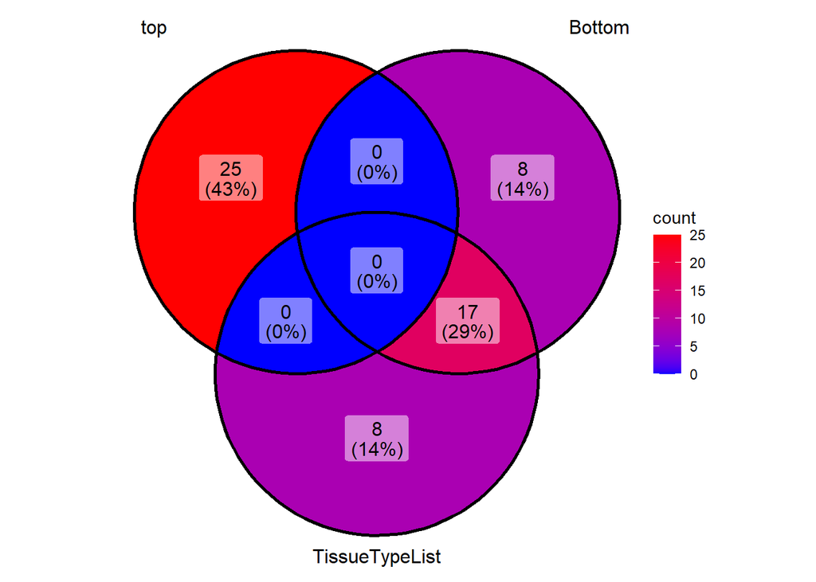

```r
# Get the top changed metabolites
top_entries <- ResList[["TissueType"]][["dma"]][["TUMOR_vs_NORMAL"]] %>%
  arrange(desc(t.val)) %>%
  slice(1:25)%>%
  select(Metabolite)%>%
  pull()
bottom_entries <- ResList[["TissueType"]][["dma"]][["TUMOR_vs_NORMAL"]] %>%
  arrange(desc(t.val)) %>%
  slice((n()-24):n())%>%
  select(Metabolite)  %>%
  pull()

# Check if those overlap with the top demographics drivers
ggVennDiagram::ggVennDiagram(list(top = top_entries,
                                  Bottom = bottom_entries,
                                  TissueTypeList = TissueTypeList))+
  ggplot2::scale_fill_gradient(low = "blue", high = "red")
```

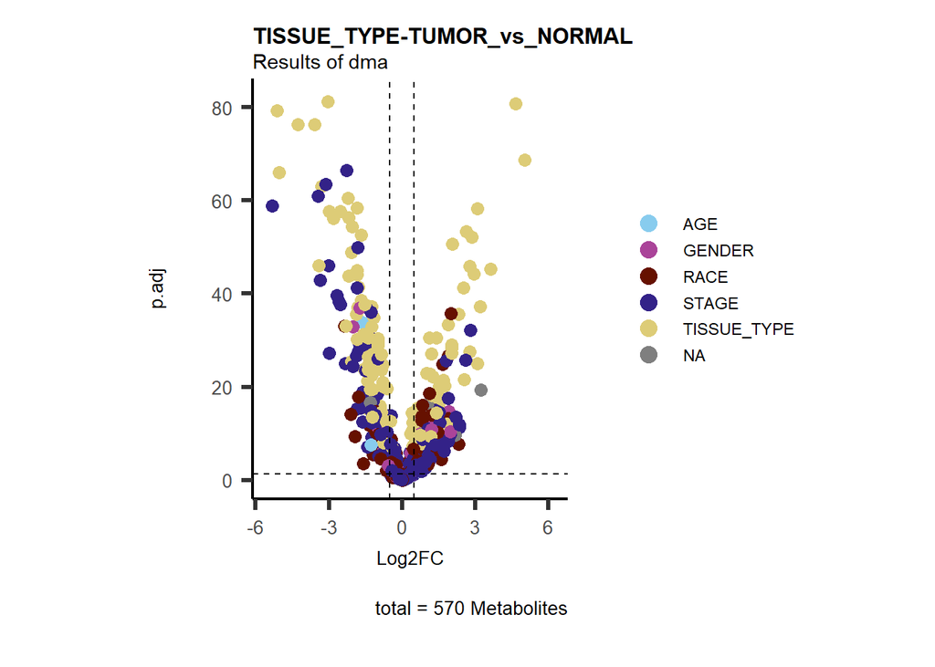

```r
MetaData_Metab <- merge(x=tissue_meta,
                   y= MetaRes[["res_summary"]][, c(1,5:6) ]%>%tibble::column_to_rownames("feature"),
                   by=0,
                   all.y=TRUE)%>%
  column_to_rownames("Row.names")

# Make a Volcano plot:
MetaProViz::viz_volcano(plot_types="Standard",
                       data=ResList[["TissueType"]][["dma"]][["TUMOR_vs_NORMAL"]]%>%tibble::column_to_rownames("Metabolite"),
                       metadata_feature =  MetaData_Metab,
                       metadata_info = c(color = "MainDriver_Term"),
                      plot_name= "TISSUE_TYPE-TUMOR_vs_NORMAL",
                       subtitle= "Results of dma" )
```

## Metabolite ID QC

Before we perform enrichment analysis,it is important to check the availability of metabolite IDs that we aim to use. We can first create an overview plot:

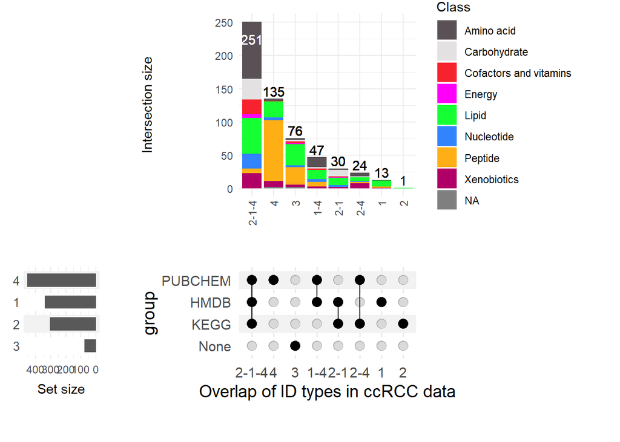

```r
# Make folder for HMDB results:
if (!dir.exists("MetaProViz_Results/PK")) {
  dir.create("MetaProViz_Results/PK", recursive = TRUE)
}

if (!dir.exists("MetaProViz_Results/PK/Original")) {
  dir.create("MetaProViz_Results/PK/Original", recursive = TRUE)
}
if (!dir.exists("MetaProViz_Results/PK/PK_HMDB")) {
  dir.create("MetaProViz_Results/PK/PK_HMDB", recursive = TRUE)
}

if (!dir.exists("MetaProViz_Results/PK/PK_HMDB/Original")) {
  dir.create("MetaProViz_Results/PK/PK_HMDB/Original", recursive = TRUE)
}



#Load the feature metadata:
MetaboliteIDs <- Tissue_MetaData %>%
  rownames_to_column("Metabolite")%>%
  dplyr::rename("HMDB"= "Group_HMDB")%>%
  slice(1:577)# only keep entries with trivial names

ccRCC_CompareIDs <- MetaProViz::compare_pk(data = list(Biocft = MetaboliteIDs |> dplyr::rename("Class"="SUPER_PATHWAY")),
                                           name_col = "Metabolite",
                                           metadata_info = list(Biocft = c("KEGG", "HMDB", "PUBCHEM")),
                                           plot_name = "Overlap of ID types in ccRCC data",
                                           path= "MetaProViz_Results/PK/Original")
```

Here we notice that 76 features have no metabolite ID assigned, yet have a trivial name and a metabolite class assigned. For 135 metabolites we only have a pubchem ID, yet no HMDB or KEGG ID. Next, we will try to understand the missing IDs focusing on HMDb as an example:

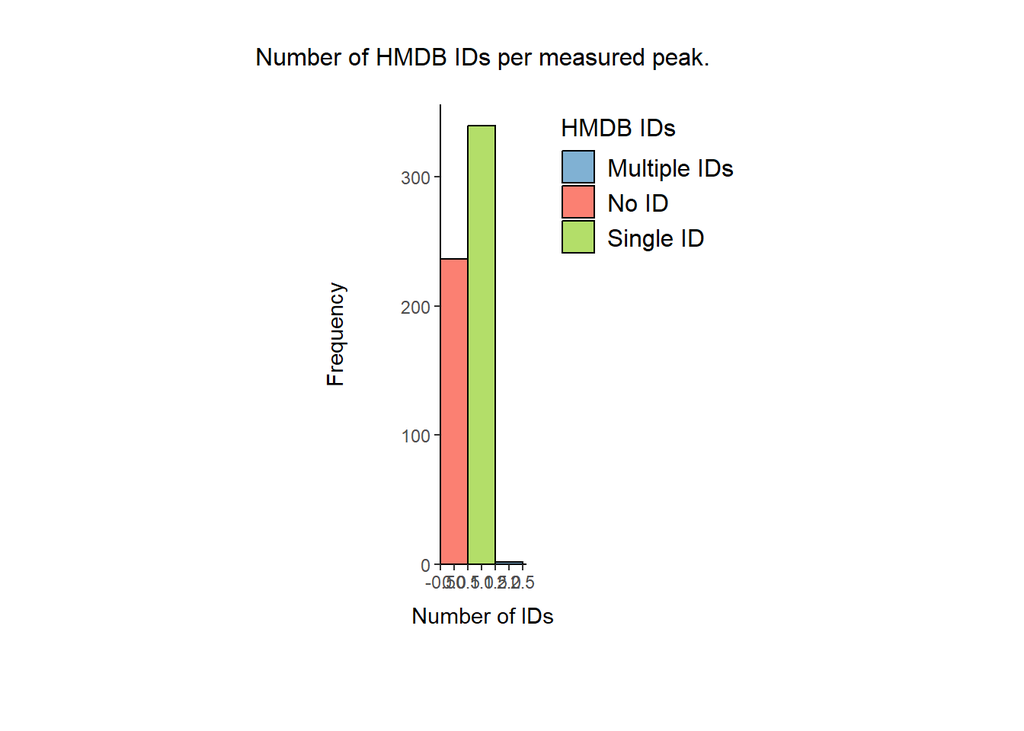

```r
Plot1_HMDB <- MetaProViz::count_id(MetaboliteIDs,
                                   "HMDB",
                                   path = "MetaProViz_Results/PK/PK_HMDB/Original")
```

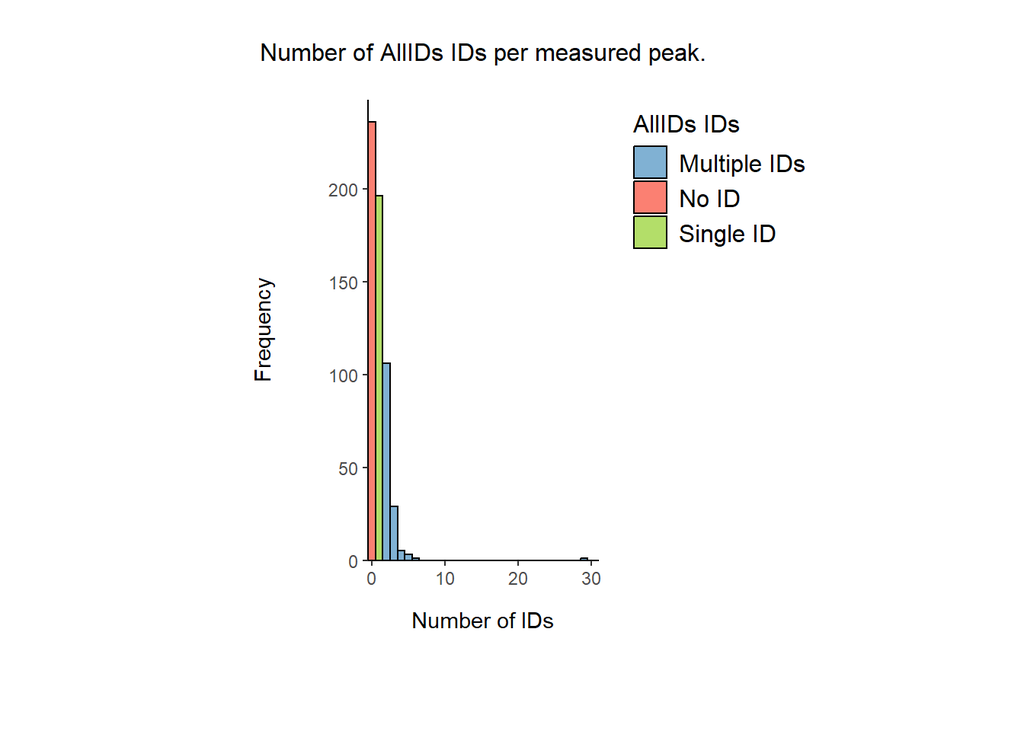

```r
# Make folder for HMDB results:
if (!dir.exists("MetaProViz_Results/PK/PK_HMDB/PlusEquivalentIDs")) {
  dir.create("MetaProViz_Results/PK/PK_HMDB/PlusEquivalentIDs", recursive = TRUE)
}

# Input
Input_HMDB <- MetaboliteIDs %>%
  dplyr::filter(!is.na(HMDB)) %>% # ID in the measured data we want to use, hence we remove NA's
  dplyr::select("Metabolite", "HMDB", "SUPER_PATHWAY") # only keep relevant columns

# Add equivalent IDs:
tissue_meta_AddIDs_HMDB <- MetaProViz::equivalent_id(data= Input_HMDB,
                                                           metadata_info = c(InputID="HMDB"),# ID in the measured data, here we use the HMDB ID
                                                           from = "hmdb",
                                                     path= "MetaProViz_Results/PK/PK_HMDB/PlusEquivalentIDs")
# Let's see how this has changed the number of entries:
tissue_meta_AddIDs_HMDB <- merge(x=MetaboliteIDs,
                                       y=tissue_meta_AddIDs_HMDB,
                                       by="HMDB",
                                       all.x=TRUE)

# Plot 2 after equivalent IDs where added
Plot2_HMDB <- MetaProViz::count_id(tissue_meta_AddIDs_HMDB,
                                   "AllIDs",
                                   path = "MetaProViz_Results/PK/PK_HMDB/PlusEquivalentIDs")
```

Additionally, for the metabolites without HMDB ID we can check if a HMDB ID is available using the other ID types. First we check if we have cases in which we do have no HMDB ID, but other available IDs:

Overview of other ID types for metabolites without HMDB ID.

| Total_Cases | Not_NA_PUBCHEM | Not_NA_KEGG | Both_Not_NA |
| --- | --- | --- | --- |
| 160 | 159 | 25 | 24 |

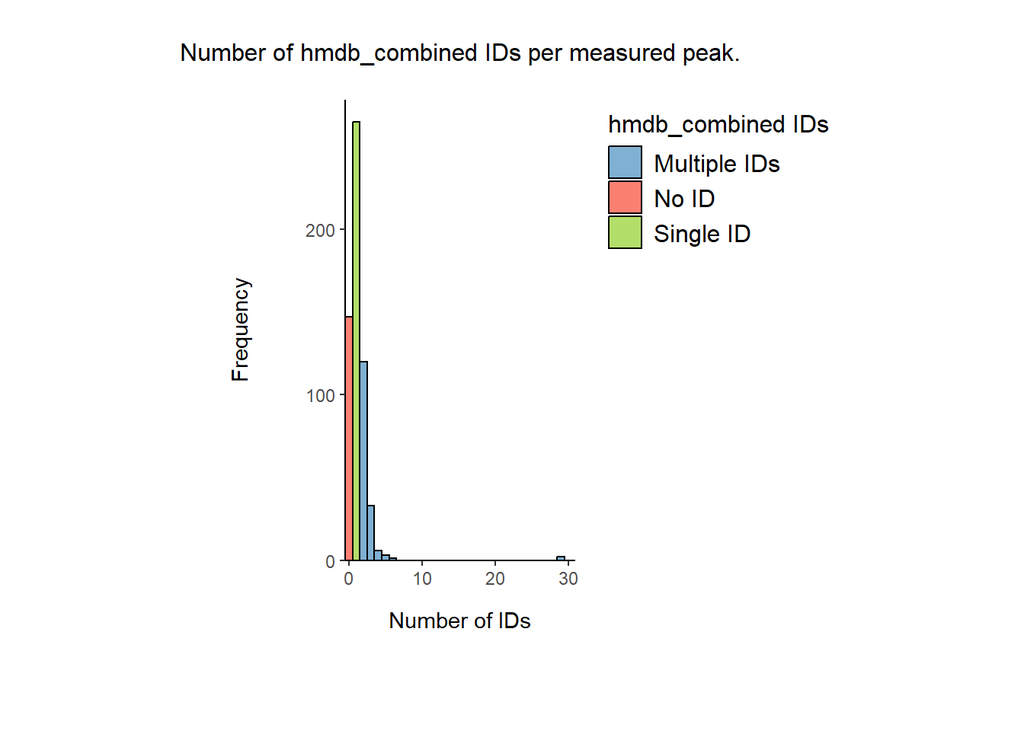

```r
# Make folder for HMDB results:
if (!dir.exists("MetaProViz_Results/PK/PK_HMDB/PlusTranslatedIDs")) {
  dir.create("MetaProViz_Results/PK/PK_HMDB/PlusTranslatedIDs", recursive = TRUE)
}

if (!dir.exists("MetaProViz_Results/PK/PK_HMDB/PlusTranslatedIDs/PubChem")) {
  dir.create("MetaProViz_Results/PK/PK_HMDB/PlusTranslatedIDs/PubChem", recursive = TRUE)
}

if (!dir.exists("MetaProViz_Results/PK/PK_HMDB/PlusTranslatedIDs/KEGG")) {
  dir.create("MetaProViz_Results/PK/PK_HMDB/PlusTranslatedIDs/KEGG", recursive = TRUE)
}

if (!dir.exists("MetaProViz_Results/PK/PK_HMDB/Adapted")) {
  dir.create("MetaProViz_Results/PK/PK_HMDB/Adapted", recursive = TRUE)
}

# Input
no_hmdb <- dplyr::filter(MetaboliteIDs, is.na(HMDB) & (!is.na(PUBCHEM) | !is.na(KEGG)))

tissue_meta_translated_HMDB <-
  MetaProViz::translate_id(no_hmdb,
                           metadata_info = list(InputID = "PUBCHEM", grouping_variable = "SUPER_PATHWAY"),
                           from = "pubchem",
                           to = "hmdb",
                           path="MetaProViz_Results/PK/PK_HMDB/PlusTranslatedIDs/PubChem") |>
  extract2("TranslatedDF") |>
  rename(hmdb_from_pubchem = hmdb) |>
  MetaProViz::translate_id(metadata_info = list(InputID = "KEGG", grouping_variable = "SUPER_PATHWAY"),
                           from = "kegg",
                           to = "hmdb",
                           path="MetaProViz_Results/PK/PK_HMDB/PlusTranslatedIDs/KEGG") |>
  extract2("TranslatedDF") |>
  rename(hmdb_from_kegg = hmdb)
# Here we combine the tables above, created by equivalent_id and translate_id:
Tissue_MetaData_HMDB <-
  left_join(
    tissue_meta_AddIDs_HMDB |>
      select(Metabolite = Metabolite.x, SUPER_PATHWAY = SUPER_PATHWAY.x, SUB_PATHWAY ,COMP_ID, PLATFORM, RI, MASS, CAS, PUBCHEM, KEGG,  HMDB, hmdb_from_equivalentid = AllIDs),
    tissue_meta_translated_HMDB |>
      select(COMP_ID, hmdb_from_pubchem, hmdb_from_kegg) |> mutate(across(starts_with("hmdb_from"), ~na_if(., ""))),
    by = 'COMP_ID'
  ) |>
  rowwise() |>
  mutate(hmdb_combined = list(unique(na.omit(unlist(stringr::str_split(across(starts_with("hmdb_from")), ",")))))) |>
  mutate(hmdb_combined = paste0(hmdb_combined, collapse = ',')) |>  # we concatenate by "," only for the sake of printing in notebook
  ungroup()

#Let's save the combined tables:
write.csv(tissue_meta_translated_HMDB, "MetaProViz_Results/PK/PK_HMDB/PlusTranslatedIDs/Translated_Tissue_MetaData_PUBCHEM-HMDB_and_KEGG-HMDB.csv", row.names = FALSE)
write.csv(Tissue_MetaData_HMDB, "MetaProViz_Results/PK/PK_HMDB/Adapted/Adapted_Tissue_MetaData_HMDB.csv", row.names = FALSE)

# Plot 3:
Plot3_HMDB <- MetaProViz::count_id(Tissue_MetaData_HMDB,
                                   "hmdb_combined",
                                   path="MetaProViz_Results/PK/PK_HMDB/Adapted")
```

If we inspect the tables we can check that for example, 16-hydroxypalmitate certainly has an HMDB ID, yet was missing from the original metadata table. We can check the structures associated to it on [PubChem:10466](https://pubchem.ncbi.nlm.nih.gov/compound/10466) and [KEGG:C18218](https://www.genome.jp/entry/C18218) are indeed identical, and as we expect, the same structure is in HMDB too, under the ID HMDB0006294.  
We can of course do the same for other IDs, such as the KEGG IDs:

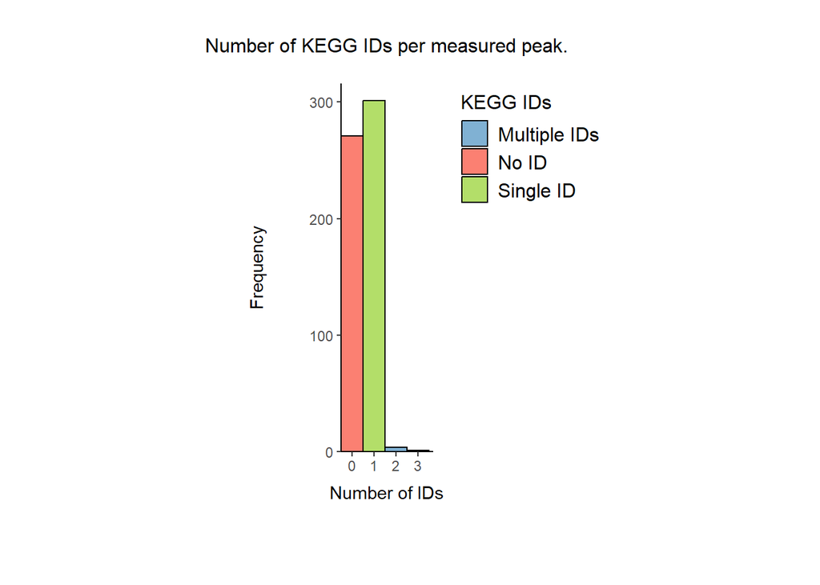

```r
# Make folder for KEGG results:
if (!dir.exists("MetaProViz_Results/PK/PK_KEGG")) {
  dir.create("MetaProViz_Results/PK/PK_KEGG", recursive = TRUE)
}

if (!dir.exists("MetaProViz_Results/PK/PK_KEGG/Original")) {
  dir.create("MetaProViz_Results/PK/PK_KEGG/Original", recursive = TRUE)
}


Plot1_KEGG <- MetaProViz::count_id(MetaboliteIDs,
                                   "KEGG",
                                   path= "MetaProViz_Results/PK/PK_KEGG/Original")
```

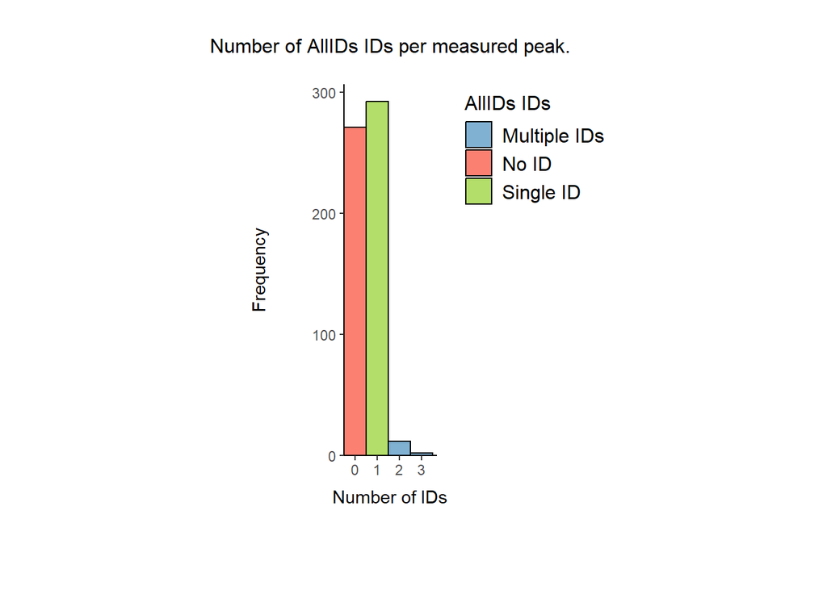

```r
##################################################################################################################
if (!dir.exists("MetaProViz_Results/PK/PK_KEGG/PlusEquivalentIDs")) {
  dir.create("MetaProViz_Results/PK/PK_KEGG/PlusEquivalentIDs", recursive = TRUE)
}

Input_KEGG <- Tissue_MetaData_HMDB %>%
  dplyr::filter(!is.na(KEGG)) %>% # ID in the measured data we want to use, hence we remove NA's
  dplyr::select("Metabolite", "KEGG", "SUPER_PATHWAY") # only keep relevant columns

# Add equivalent IDs:
tissue_meta_AddIDs_KEGG <- MetaProViz::equivalent_id(data= Input_KEGG,
                                                metadata_info = c(InputID="KEGG"),# ID in the measured data, here we use the HMDB ID
                                                from = "kegg",
                                                path= "MetaProViz_Results/PK/PK_KEGG/PlusEquivalentIDs")
# Let's see how this has changed the number of entries:
tissue_meta_AddIDs_KEGG <- merge(x=Tissue_MetaData_HMDB,
                                 y=tissue_meta_AddIDs_KEGG,
                                 by="KEGG",
                                 all.x=TRUE)

Plot2_KEGG <-  MetaProViz::count_id(tissue_meta_AddIDs_KEGG,
                                    "AllIDs",
                                    path= "MetaProViz_Results/PK/PK_KEGG/PlusEquivalentIDs")
```

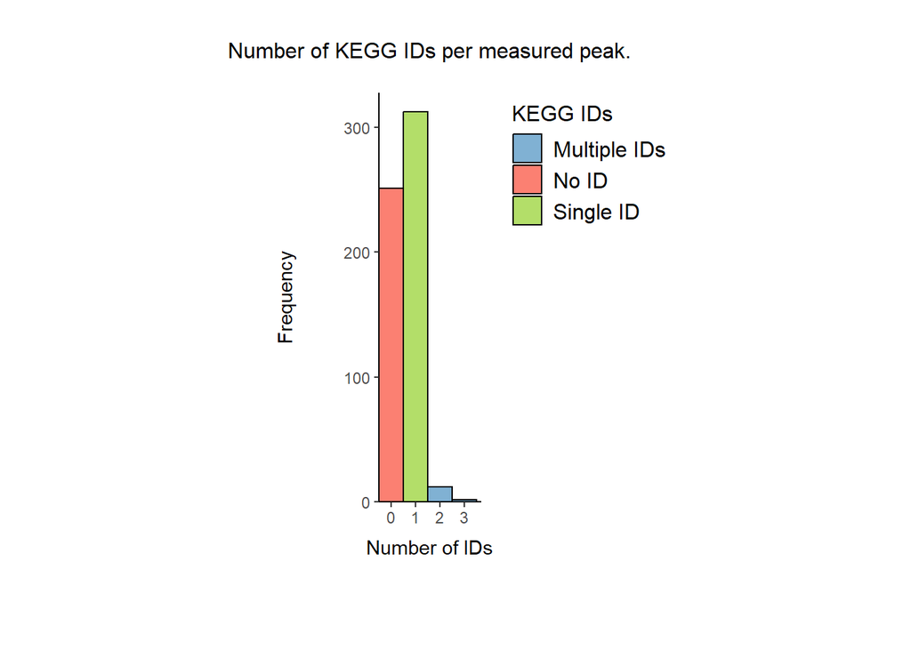

```r
###################################################################################################################
# Make folder for HMDB results:
if (!dir.exists("MetaProViz_Results/PK/PK_KEGG/PlusTranslatedIDs")) {
  dir.create("MetaProViz_Results/PK/PK_KEGG/PlusTranslatedIDs", recursive = TRUE)
}

if (!dir.exists("MetaProViz_Results/PK/PK_KEGG/PlusTranslatedIDs/PubChem")) {
  dir.create("MetaProViz_Results/PK/PK_KEGG/PlusTranslatedIDs/PubChem", recursive = TRUE)
}

if (!dir.exists("MetaProViz_Results/PK/PK_KEGG/PlusTranslatedIDs/HMDB")) {
  dir.create("MetaProViz_Results/PK/PK_KEGG/PlusTranslatedIDs/HMDB", recursive = TRUE)
}

if (!dir.exists("MetaProViz_Results/PK/PK_KEGG/Adapted")) {
  dir.create("MetaProViz_Results/PK/PK_KEGG/Adapted", recursive = TRUE)
}

no_KEGG <- dplyr::filter(Tissue_MetaData_HMDB, is.na(KEGG) & (!is.na(PUBCHEM) | !is.na(HMDB)))

tissue_meta_translated_KEGG <-
  MetaProViz::translate_id(no_KEGG, metadata_info = list(InputID = "PUBCHEM", grouping_variable = "SUPER_PATHWAY"), from = "pubchem", to = "kegg", path="MetaProViz_Results/PK/PK_KEGG/PlusTranslatedIDs/PubChem") |>
  extract2("TranslatedDF") |>
  rename(kegg_from_pubchem = kegg) |>
  MetaProViz::translate_id(metadata_info = list(InputID = "HMDB", grouping_variable = "SUPER_PATHWAY"), from = "hmdb", to = "kegg", path="MetaProViz_Results/PK/PK_KEGG/PlusTranslatedIDs/HMDB") |>
  extract2("TranslatedDF") |>
  rename(kegg_from_hmdb = kegg)
# here we combine the tables above, created by equivalent_id and translate_id:
Tissue_MetaData_KEGG <-
  left_join(
    tissue_meta_AddIDs_KEGG |>
      select(Metabolite = Metabolite.x, SUPER_PATHWAY = SUPER_PATHWAY.x,SUB_PATHWAY, COMP_ID, PLATFORM, RI, MASS, CAS, PUBCHEM, HMDB=hmdb_combined , HMDB_Original = HMDB, hmdb_from_equivalentid, hmdb_from_kegg, hmdb_from_pubchem, , KEGG_Original = KEGG, kegg_from_equivalentid = AllIDs),
    tissue_meta_translated_KEGG |>
      select(COMP_ID, kegg_from_pubchem, kegg_from_hmdb) |> mutate(across(starts_with("kegg_from"), ~na_if(., ""))),
    by = 'COMP_ID'
  ) |>
  rowwise() |>
  mutate(KEGG= list(unique(na.omit(unlist(stringr::str_split(across(starts_with("kegg_from")), ",")))))) |>
  mutate(KEGG = paste0(KEGG, collapse = ',')) |>  # we concatenate by "," only for the sake of printing in notebook
  ungroup()

#Let's save the combined tables:
write.csv(tissue_meta_translated_KEGG, "MetaProViz_Results/PK/PK_KEGG/PlusTranslatedIDs/Translated_Tissue_MetaData_PUBCHEM-KEGG_and_HMDB-KEGG.csv", row.names = FALSE)
write.csv(Tissue_MetaData_KEGG, "MetaProViz_Results/PK/PK_KEGG/Adapted/Adapted_Tissue_MetaData_KEGG.csv", row.names = FALSE)

# Lets see the count now:
Plot3_KEGG <- MetaProViz::count_id(Tissue_MetaData_KEGG,
                                   "KEGG",
                                   path= "MetaProViz_Results/PK/PK_KEGG/Adapted")
```

```r
#Save panel plot:
row1 <- cowplot ::plot_grid(Plot1_HMDB[["Plot_Sized"]], Plot2_HMDB[["Plot_Sized"]], Plot3_HMDB[["Plot_Sized"]], ncol = 3, labels = c("A", "B", "C"),
    #rel_widths = c(0.85, 0.85, 1.3),
    label_size = 20)
row2 <- cowplot ::plot_grid(Plot1_KEGG[["Plot_Sized"]], Plot2_KEGG[["Plot_Sized"]] ,Plot3_KEGG[["Plot_Sized"]], ncol = 3, labels = c("D", "E", "F"),
    label_size = 20)
g <- cowplot ::plot_grid(row1, row2, ncol = 1, rel_heights = c(1, 1))

ggplot2::ggsave(filename = "MetaProViz_Results/PK/Bargraphs_FrequencyIDs.svg",
    plot = g,
    device = "svg",
    dpi = 600,
    width = 10.5,
    height = 8)
```

Lastly, we will have the new metadata table, which we can use for enrichment analysis:

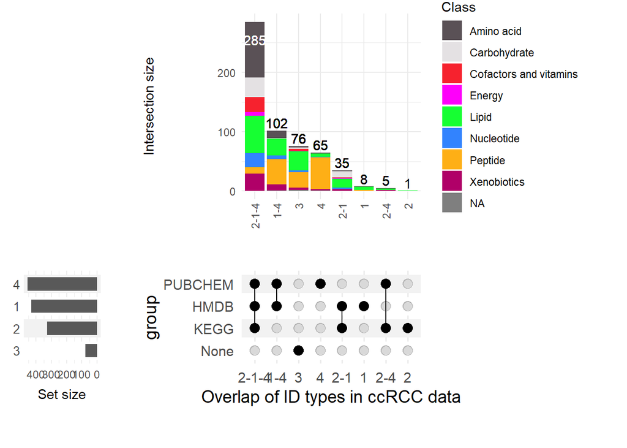

```r
if (!dir.exists("MetaProViz_Results/PK/Adapted")) {
  dir.create("MetaProViz_Results/PK/Adapted", recursive = TRUE)
}

Tissue_MetaData_Extended <-  Tissue_MetaData_KEGG[, c(1:10,19, 11:18)]%>%
  mutate(
    KEGG = ifelse(KEGG == "", NA, KEGG),
    HMDB = ifelse(HMDB == "", NA, HMDB)
  )

write.csv(Tissue_MetaData_KEGG, "MetaProViz_Results/PK/Adapted/Adapted_Tissue_MetaData.csv", row.names = FALSE)

ccRCC_CompareIDs_Extended <- MetaProViz::compare_pk(data = list(Biocft = Tissue_MetaData_Extended |> dplyr::rename("Class"="SUPER_PATHWAY")),
                                                    name_col = "Metabolite",
                                                    metadata_info = list(Biocft = c("KEGG", "HMDB", "PUBCHEM")),
                                                    plot_name = "Overlap of ID types in ccRCC data",
                                                    path="MetaProViz_Results/PK/Adapted")
```

```r
Upset_panel <- cowplot ::plot_grid(ccRCC_CompareIDs[["upset_plot"]], ccRCC_CompareIDs_Extended[["upset_plot"]], ncol = 2, labels = c("A", "B"),
    label_size = 20)

ggplot2::ggsave(filename = "MetaProViz_Results/PK/UpsetPlotsIDs.svg",
    plot = Upset_panel,
    device = "svg",
    dpi = 600,
    width = 12,
    height = 8)
```

If we compare the results to the upset plot from the original metadata we can see that initially 251 metabolites had a pubchem, HMDB and KEGG ID, whilst after adding the equivalent IDs and translating the IDs, we now have 285 metabolites with all three IDs. 135 metabolite had only a Pubchem ID, whilst now we have found HMDB and/or KEGG IDs for half of these metabolites with only 65 metabolites remaining with only a Pubchem ID.

## ORA

We can perform Over Representation Analysis (`ORA`) using KEGG pathways for each comparison and plot significant pathways. Noteworthy, since not all metabolites have KEGG IDs, we will lose information.

Given that in some cases we have multiple KEGG IDs for a measured feature, we will check if this causes mapping to multiple, different entries in the KEGG pathway-metabolite sets:

```r
#Load Kegg pathways:
KEGG_Pathways <- metsigdb_kegg()

#check mapping with metadata

ccRCC_to_KEGGPathways <- MetaProViz::checkmatch_pk_to_data(data = Tissue_MetaData_Extended,
                                                           input_pk = KEGG_Pathways,
                                                           metadata_info = c(InputID = "KEGG", PriorID = "MetaboliteID", grouping_variable = "term"))
problems_terms <- ccRCC_to_KEGGPathways[["GroupingVariable_summary"]]%>%
  filter(!Group_Conflict_Notes== "None")
```

Terms in KEGG pathways where the same measured feature mapps with more than one ID, which will inflate the enrichment analysis.

| KEGG | original_count | matches_count | MetaboliteID | term |
| --- | --- | --- | --- | --- |
| C00221, C00031 | 2 | 2 | C00031 | Biosynthesis of secondary metabolites |
| C00221, C00031 | 2 | 2 | C00221 | Biosynthesis of secondary metabolites |
| C00221, C00031 | 2 | 2 | C00031 | Metabolic pathways |
| C00221, C00031 | 2 | 2 | C00031 | Glycolysis / Gluconeogenesis |
| C00221, C00031 | 2 | 2 | C00221 | Pentose phosphate pathway |
| C00221, C00031 | 2 | 2 | C00031 | Pentose phosphate pathway |
| C00221, C00031 | 2 | 2 | C00221 | Metabolic pathways |
| C00221, C00031 | 2 | 2 | C00221 | Glycolysis / Gluconeogenesis |
| C03460, C03722 | 2 | 2 | C03722 | Metabolic pathways |
| C03460, C03722 | 2 | 2 | C03460 | Metabolic pathways |
| C17737, C00695 | 2 | 2 | C17737 | Secondary bile acid biosynthesis |
| C17737, C00695 | 2 | 2 | C00695 | Secondary bile acid biosynthesis |

Dependent on the biological question and the organism and prior knowledge, one can either maintain the metabolite ID of the more likely metabolite (e.g. in human its moire likely that we have L-aminoacid than D-aminoacid) or the metabolite ID that is represented in more/less pathways (specificity). If we are looking into the cases where we do have multiple IDs, for cases with no match to the prior knowledge we can just maintain one ID, whilst for cases with exactly one match we should maintain the ID that is found in the prior knowledge.

```r
# Select the cases where a feature has multiple IDs
multipleIDs <- ccRCC_to_KEGGPathways[["data_summary"]]%>%
  filter(original_count>1)
```

Terms in KEGG pathways where the same measured feature mapps with more than one ID, which may inflate the enrichment analysis.

| KEGG | InputID_select | original_count | matches_count | matches | Group_Conflict_Notes | ActionRequired | Action_Specific |
| --- | --- | --- | --- | --- | --- | --- | --- |
| C00065, C00716 | NA | 2 | 2 | C00065, C00716 | None | Check | KeepEachID |
| C00155, C05330 | C00155 | 2 | 1 | C00155 | None | None | None |
| C00221, C00031 | NA | 2 | 2 | C00221, C00031 | None \|\| Biosynthesis of secondary metabolites \|\| Metabolic pathways \|\| Glycolysis / Gluconeogenesis \|\| Pentose phosphate pathway | Check | KeepOneID |
| C00671, C06008 | C00671 | 2 | 1 | C00671 | None | None | None |
| C01835, C00721, C00420 | NA | 3 | 2 | C01835, C00721 | None | Check | KeepEachID |
| C01991, C00989 | C00989 | 2 | 1 | C00989 | None | None | None |
| C02052, C00464 | C00464 | 2 | 1 | C00464 | None | None | None |
| C03460, C03722 | NA | 2 | 2 | C03460, C03722 | None \|\| Metabolic pathways | Check | KeepOneID |
| C07202,D02358 | C07202 | 2 | 0 | NA | None | None | None |
| C17737, C00695 | NA | 2 | 2 | C17737, C00695 | Secondary bile acid biosynthesis \|\| None | Check | KeepOneID |
| D00095,C00788,D02149 | C00788 | 3 | 1 | C00788 | None | None | None |
| D00567,C07589 | D00567 | 2 | 0 | NA | None | None | None |
| D00887,C06834 | D00887 | 2 | 0 | NA | None | None | None |
| D02362,C07415 | D02362 | 2 | 0 | NA | None | None | None |

In case of `ActionRequired=="Check"`, we can look into the column `Action_Specific` which contains additional information. In case of the entry `KeepEachID`, multiple matches to the prior knowledge were found, yet the features are in different pathways (=GroupingVariable). Yet, in case of `KeepOneID`, the different IDs map to the same pathway in the prior knowledge for at least one case and therefore keeping both would inflate the enrichment analysis.

```r
SelectedIDs <- ccRCC_to_KEGGPathways[["data_summary"]]%>%
  #Expand rows where Action == KeepEachID by splitting `matches`
  dplyr::mutate(matches_split = if_else(Action_Specific == "KeepEachID", matches, NA_character_)) %>%
  separate_rows(matches_split, sep = ",\\s*") %>%
  mutate(InputID_select = if_else(Action_Specific  == "KeepEachID", matches_split, InputID_select)) %>%
  select(-matches_split) %>%
  #Select one ID for AcionSpecific==KeepOneID
  dplyr::mutate(InputID_select = case_when(
    Action_Specific == "KeepOneID" & matches == "C03460, C03722" ~ "C03722", # 2-Methylprop-2-enoyl-CoA versus Quinolinate. No evidence, hence we keep the one present in more pathways ( C03722=7 pathways, C03460=2 pathway)
    Action_Specific == "KeepOneID" & matches ==  "C00221, C00031" ~ "C00031", # These are D- and L-Glucose. We have human samples, so in this conflict we will maintain L-Glucose
    Action_Specific == "KeepOneID" & matches ==  "C17737, C00695" ~ "C00695", # Allocholic acid versus Cholic acid. No evidence, hence we keep the one present in more pathways (C00695 = 4 pathways, C17737 = 1 pathway)
    Action_Specific == "KeepOneID" ~ InputID_select,  # Keep NA where not matched manually
    TRUE ~ InputID_select
  ))
```

Lastly, we need to add the column including our selected IDs to the metadata table:

```r
Tissue_MetaData_Extended <- merge(x= SelectedIDs %>%
                                        dplyr::select(KEGG, InputID_select),
                                  y= Tissue_MetaData_Extended,
                                  by= "KEGG",
                                  all.y=TRUE)
```

For results with p.adjusted value < 0.1 and a minimum of 10% of the pathway detected will be visualized as Volcano plots:

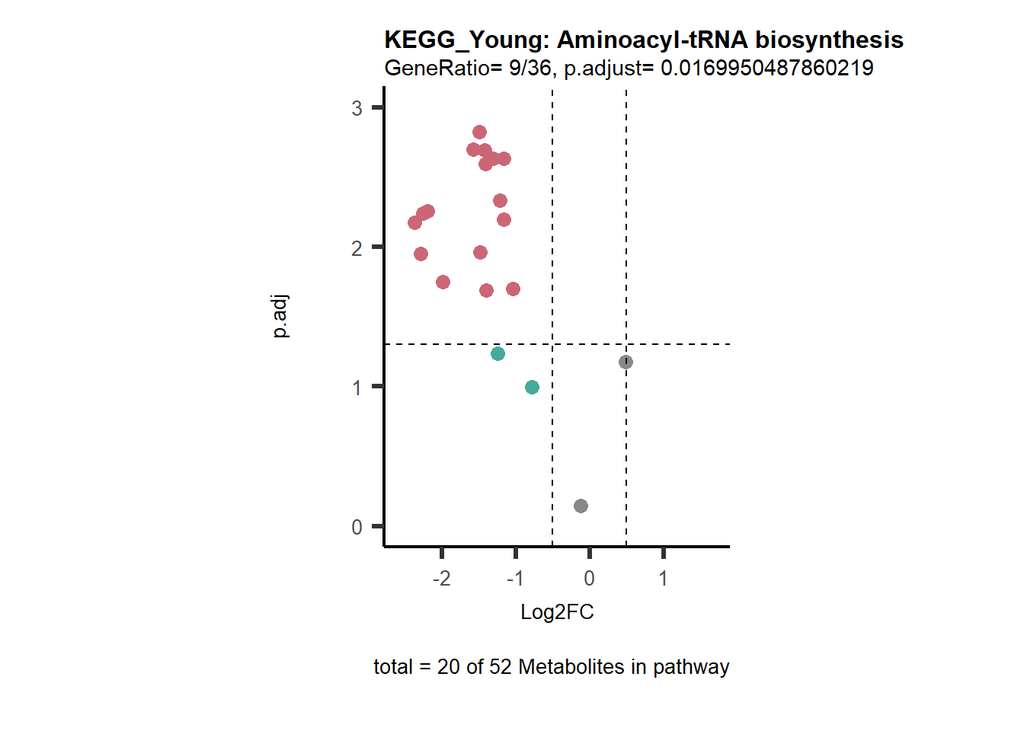

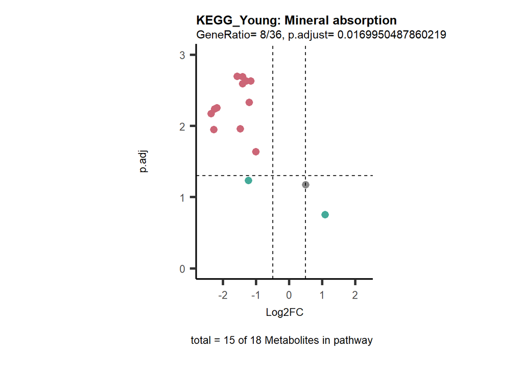

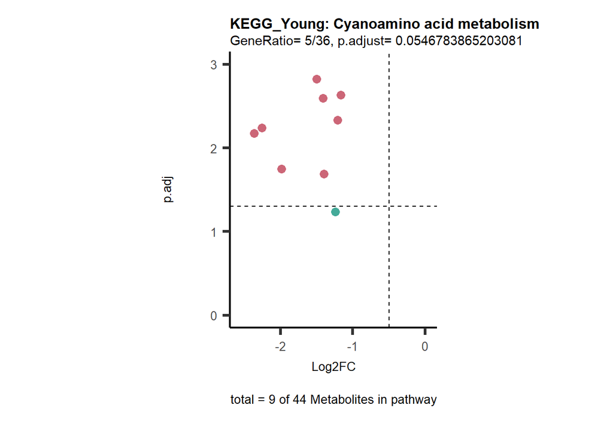

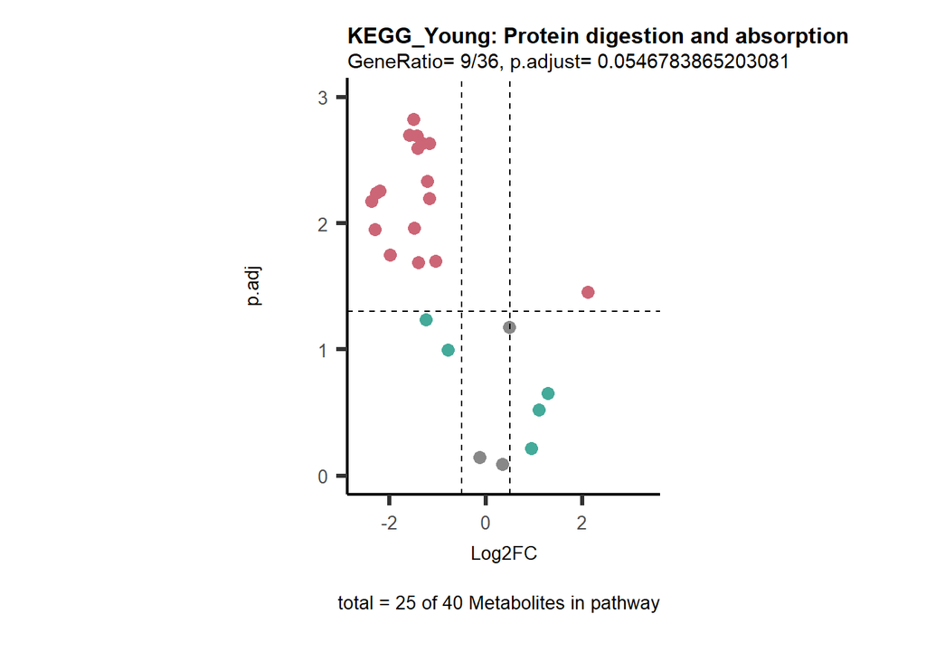

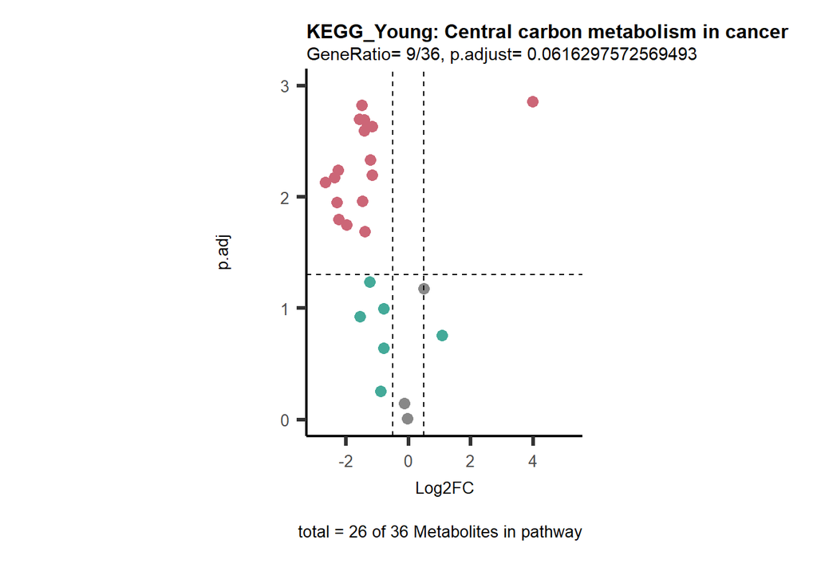

```r
# Since we have performed multiple comparisons (all_vs_HK2), we will run ORA for each of this comparison
DM_ORA_res<- list()

for(comparison in names(ResList)){#Res list includes the different comparisons we performed above <-
  #Ensure that the Metabolite names match with KEGG IDs or KEGG trivial names.
  dma_res <- merge(x= Tissue_MetaData_Extended,
                   y= ResList[[comparison]][["dma"]][["TUMOR_vs_NORMAL"]],
                   by="Metabolite",
                   all=TRUE)

  #Ensure unique IDs and full background --> we include measured features that do not have a KEGG ID.
  dma_res <- dma_res[,c(3,21:25)]%>%
    dplyr::mutate(InputID_select = if_else(
      is.na(InputID_select),
      paste0("NA_", cumsum(is.na(InputID_select))),
      InputID_select
      ))%>% #remove duplications and keep the higher Log2FC measurement
    group_by(InputID_select) %>%
    slice_max(order_by = Log2FC, n = 1, with_ties = FALSE) %>%
    ungroup()%>%
    remove_rownames()%>%
    tibble::column_to_rownames("InputID_select")

  #Perform ORA
  set.seed(100)
  Res <- MetaProViz::standard_ora(data= dma_res, #Input data requirements: column `t.val` and column `Metabolite`
                                 metadata_info=c(pvalColumn="p.adj", percentageColumn="t.val", PathwayTerm= "term", PathwayFeature= "MetaboliteID"),
                                 input_pathway=KEGG_Pathways,#Pathway file requirements: column `term`, `Metabolite` and `Description`. Above we loaded the Kegg_Pathways using MetaProViz::Load_KEGG()
                                 pathway_name=paste0("KEGG_", comparison, sep=""),
                                 min_gssize=3,
                                 max_gssize=1000,
                                 cutoff_stat=0.01,
                                 cutoff_percentage=10)

  DM_ORA_res[[comparison]] <- Res

  #Select to plot:
  Res_Select <- Res[["ClusterGosummary"]]%>%
    filter(p.adjust<0.1)%>%
    #filter(pvalue<0.05)%>%
    filter(percentage_of_Pathway_detected>10)

  if(is.null(Res_Select)==FALSE){
     MetaProViz::viz_volcano(plot_types="PEA",
                       data= dma_res, #Must be the data you have used as an input for the pathway analysis
                       data2=as.data.frame(Res_Select )%>%dplyr::rename("term"="ID"),
                       metadata_info= c(PEA_Pathway="term",# Needs to be the same in both, metadata_feature and data2.
                                       PEA_stat="p.adjust",#Column data2
                                       PEA_score="GeneRatio",#Column data2
                                       PEA_Feature="MetaboliteID"),# Column metadata_feature (needs to be the same as row names in data)
                       metadata_feature= KEGG_Pathways,#Must be the pathways used for pathway analysis
                       plot_name= paste("KEGG_", comparison, sep=""),
                       subtitle= "PEA" )
  }
}
```

## Biological regulated clustering

to understand which metabolites are changing independent of the patients age, hence only due to tumour versus normal, and which metabolites change independent of tumour versus normal, hence due to the different age, we can use the `MetaProViz::mca_2cond()` function.  
Metabolite Clustering Analysis (`MCA`) enables clustering of metabolites into groups based on logical regulatory rules. Here we set two different thresholds, one for the differential metabolite abundance (Log2FC) and one for the significance (e.g. p.adj). This will define if a feature (= metabolite) is assigned into:  
1. “UP”, which means a metabolite is significantly up-regulated in the underlying comparison.  
2. “DOWN”, which means a metabolite is significantly down-regulated in the underlying comparison.  
3. “No Change”, which means a metabolite does not change significantly in the underlying comparison and/or is not defined as up-regulated/down-regulated based on the Log2FC threshold chosen.  
Thereby “No Change” is further subdivided into four states:  
1. “Not Detected”, which means a metabolite is not detected in the underlying comparison.  
2. “Not Significant”, which means a metabolite is not significant in the underlying comparison.  
3. “Significant positive”, which means a metabolite is significant in the underlying comparison and the differential metabolite abundance is positive, yet does not meet the threshold set for “UP” (e.g. Log2FC >1 = “UP” and we have a significant Log2FC=0.8).  
4. “Significant negative”, which means a metabolite is significant in the underlying comparison and the differential metabolite abundance is negative, yet does not meet the threshold set for “DOWN”.  
For more information you can also check out the other vignettes.

```r
MCAres <-  MetaProViz::mca_2cond(data_c1=ResList[["Young"]][["dma"]][["TUMOR_vs_NORMAL"]],
                                 data_c2=ResList[["Old"]][["dma"]][["TUMOR_vs_NORMAL"]],
                                 metadata_info_c1=c(ValueCol="Log2FC",StatCol="p.adj", cutoff_stat= 0.05, ValueCutoff=1),
                                 metadata_info_c2=c(ValueCol="Log2FC",StatCol="p.adj", cutoff_stat= 0.05, ValueCutoff=1),
                                 feature = "Metabolite",
                                 save_table = "csv",
                                 method_background="C1&C2"#Most stringend background setting, only includes metabolites detected in both comparisons
                                 )
```

Now we can use this information to colour code our volcano plot. We will plot individual vocano plots for each metabolite pathway as defined by the feature metadata provided as part of the data in (Hakimi et al. 2016).